# Explore Weather Trend

Linda Xu

12.22.2020

**Outline** In this project, I will analyze local and global temperature data and compare the temperature trends where I live to overall global temperature trends. I choose local area Anshan, China. And I’ll be using SQL, EXCEL and R.

**Step 1: Extraction of data from database using SQL**

select * from global_data;

select * from city_data where country=‘China’ and city=’Anshan;

I download files as “results(1).csv” and “results(2).csv”.

And I manipulate two files into one, name “New update.csv”

Moving Average:

Moving averages are used to smooth out data to make it easier to observe long term trends and not get lost in daily fluctuations. I create two columns called global mov_avg and local mov_avg, which are where the moving average field will be stored. I use commend =AVERAGE(B2:B11) for global mov_avg and commend=AVERAGE(E81:E90) for local mov_avg to see the moving average value for 10 years. Note that global temperature was recorded since 1750 while local temperature was recorded since 1829.

```r
# Use ggplot2 for visualization
library(ggplot2)
library(tidyverse)
```

**Step 2: Read data and Visualization：**

```r
temp <- read.csv(file = 'C:/Users/xuwen/Desktop/Udecity/Project 1/New update.csv')
head(temp)
```

|  | year.1 | Global.avg_temp | global.mov_avg | year.2 | Anshan.avg_temp | local.mov_avg |
| --- | --- | --- | --- | --- | --- | --- |
| 1 | 1750 | 8.72 | NA | NA | NA | NA |
| 2 | 1751 | 7.98 | NA | NA | NA | NA |
| 3 | 1752 | 5.78 | NA | NA | NA | NA |
| 4 | 1753 | 8.39 | NA | NA | NA | NA |
| 5 | 1754 | 8.47 | NA | NA | NA | NA |
| 6 | 1755 | 8.36 | NA | NA | NA | NA |

```r
#start year 1829 for both local and global temperature
temp2<- read.csv(file = 'C:/Users/xuwen/Desktop/Udecity/Project 1/New update 2.csv')
head(temp2)
```

|  | year.1 | Global.avg_temp | global.mov_avg | year.2 | Anshan.avg_temp | local.mov_avg |
| --- | --- | --- | --- | --- | --- | --- |
| 1 | 1829 | 7.94 | 8.184 | 1829 | 11.80 | NA |
| 2 | 1830 | 8.52 | 8.274 | 1830 | 7.12 | NA |
| 3 | 1831 | 7.64 | 8.229 | 1831 | 6.02 | NA |
| 4 | 1832 | 7.45 | 8.155 | 1832 | 6.00 | NA |
| 5 | 1833 | 8.01 | 8.184 | 1833 | 6.59 | NA |
| 6 | 1834 | 8.15 | 8.144 | 1834 | 6.94 | NA |

**Anshan Moving Average Temperature**

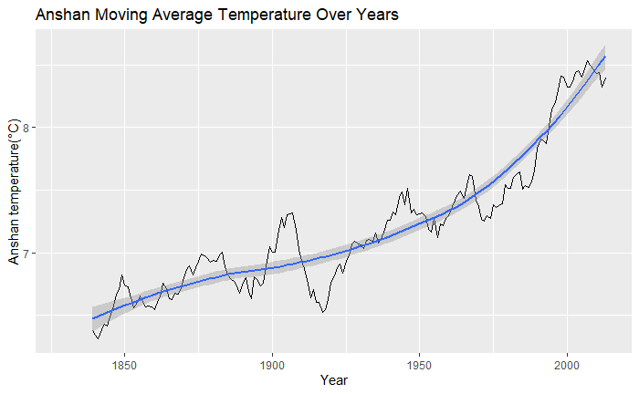

```r
temp %>%
  select(year.2, local.mov_avg)%>%
  group_by(year.2)%>%
  ggplot(aes(y= local.mov_avg, x= year.2))+ geom_line()+geom_smooth()+ ggtitle("Anshan Moving Average Temperature Over Years")+labs(y="Anshan temperature(°C)", x = "Year")
```

**Global Moving Average Temperature**

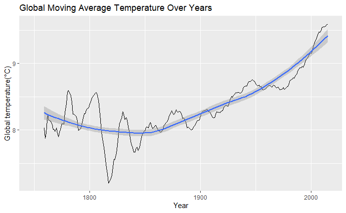

```r
temp %>%
  select(year.1, global.mov_avg)%>%
  group_by(year.1)%>%
  ggplot(aes(y= global.mov_avg, x= year.1))+ geom_line()+geom_smooth()+ ggtitle("Global Moving Average Temperature Over Years")+labs(y="Global temperature(°C)", x = "Year")
```

**Anshan and Global Moving Average Temperature**

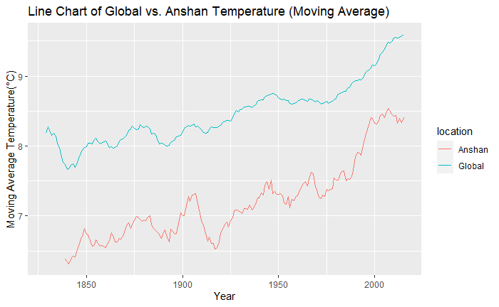

```r
ggplot(temp2, aes(year.1)) +
  geom_line(aes(y = local.mov_avg, color = "blue")) +
  geom_line(aes(y = global.mov_avg, color= "yellow"))+
ggtitle("Line Chart of Global vs. Anshan Temperature (Moving Average) ")+labs(y="Moving Average Temperature(°C)", x = "Year")+scale_color_discrete(name = "location", labels = c("Anshan", "Global"))
```

```r
summary(temp2)
```

```
     year.1     Global.avg_temp global.mov_avg      year.2     Anshan.avg_temp  local.mov_avg
 Min.   :1829   Min.   :7.380   Min.   :7.666   Min.   :1829   Min.   : 5.450   Min.   :6.314
 1st Qu.:1876   1st Qu.:8.130   1st Qu.:8.139   1st Qu.:1875   1st Qu.: 6.728   1st Qu.:6.760
 Median :1922   Median :8.500   Median :8.356   Median :1921   Median : 7.130   Median :7.101
 Mean   :1922   Mean   :8.492   Mean   :8.461   Mean   :1921   Mean   : 7.226   Mean   :7.200
 3rd Qu.:1968   3rd Qu.:8.755   3rd Qu.:8.674   3rd Qu.:1967   3rd Qu.: 7.628   3rd Qu.:7.439
 Max.   :2015   Max.   :9.830   Max.   :9.594   Max.   :2013   Max.   :11.800   Max.   :8.536
                                                NA's   :2      NA's   :3        NA's   :10
```